# Building and Validating Predictive Models for Acute Kidney Injury (AKI) using PCORnet CDM (Part II.1)

xing song

Feburary 09, 2019

### Stage 2: Predictive Models Validation (Benchmark)

In this experiment, we will build the benchmark predictive model by quasi-replicating the model by [*Koyner et al*] for AKI risk prediction on the adult inpatients at each GPC site using PCORnet common data model. This learning frame work by Koyner et al is, by far, the best reported general inpatients AKI prediction model, which is based on a tuned gradient boosting machine in a discrete time survival analysis framework with pre-selected EHR data elements. We aim to extend this benchmark prediction model by including novel elements from PCORnet CDM, while effectively automate the manual efforts of feature pre-selection and cleaning. The primary outcomes of this study were the development of AKI stage ≥ 1, AKI stage ≥ 2, and AKI stage 3 in the next 24 and 48 hours.

[*Koyner et al*] https://www.ncbi.nlm.nih.gov/pubmed/29596073

#### Preparation

By running `Part I` of “render_report.R”, the raw data tables should have already been collected and saved in the local `./data` folder (Note: these data tables are not visiable in the github ./data folder, but should be visible in the corresponding folder locally), that are

- `Table1.rda`: AKI patieht cohort table;
- `AKI_DEMO.rda`: CDM demographic table cut for AKI cohort;
- `AKI_VITAL.rda`: CDM vital table cut for AKI cohort;
- `AKI_LAB.rda`: CDM lab table cut for AKI cohort;
- `AKI_DX.rda`: CDM diagnosis table cut for AKI cohort;
- `AKI_PX.rda`: CDM procedure table cut for AKI cohort;
- `AKI_MED.rda`: CDM prescribing medication table cut for AKI cohort;

#### Objective 2.1: Data Cleaning and Representation

The final preprocessed intermediate tables from this code chunk should be found in the `./data/preproc/...` folder as the following intermediate data tables for different prediction tasks:

- For AKI stage ≥ 1 in 24 hours: `1d_rsample_idx_stg1up.rda`, `1d_var_by_yr_stg1up.rda`, `1d_var_bm_stg1up.rda`
- For AKI stage ≥ 2 in 24 hours: `1d_rsample_idx_stg2up.rda`, `1d_var_by_yr_stg2up.rda`, `1d_var_bm_stg2up.rda`
- For AKI stage = 3 in 24 hours: `1d_rsample_idx_stg3.rda`, `1d_var_by_yr_stg3.rda`, `1d_var_bm_stg3.rda`
- For AKI stage ≥ 1 in 48 hours: `2d_rsample_idx_stg1up.rda`, `2d_var_by_yr_stg1up.rda`, `1d_var_bm_stg1up.rda`
- For AKI stage ≥ 2 in 48 hours: `2d_rsample_idx_stg2up.rda`, `2d_var_by_yr_stg2up.rda`, `1d_var_bm_stg2up.rda`
- For AKI stage = 3 in 48 hours: `2d_rsample_idx_stg3.rda`, `2d_var_by_yr_stg3.rda`, `1d_var_bm_stg3.rda`

#### Objective 2.2: Benchmark Model Development

For each prediction task, defined as “predict AKI stage X in Y days, with/without Scr”, 4 intermedicate data files have been generated and saved in `./data/model_ref/...`, which are:

- `..._hyperpar_gbm_...rda`: the final hyper-parameter sets after tunning;
- `..._model_gbm_...rda`: the final gbm model after tunning;
- `..._valid_gbm_...rda`: the predictted probability on validataion set;
- `..._varimp_gbm_...rda`: the final list of variable importance

#### Objective 2.3: Performance Evaluations for Benchmark Model

#### Task I: 24-hour advanced prediction

*(I.a) Overall Prediction Performance*

Table1 - 24-Hour Prediction of AKI1, AKI2, AKI3

| pred_task | pred_in_d | fs_type | 1.ROAUC | 2.PRAUC | 3.Optimal Sensitivity | 4.Optimal Specificity | 5.Optimal Positive Predictive Value | 6.Optimal Negative Predictive Value |
| --- | --- | --- | --- | --- | --- | --- | --- | --- |
| a.AKI>=1 | 1 | no_fs | 0.8142 (0.8089,0.8196) | 0.1058 | 0.7372 | 0.7367 | 0.0472 | 0.9937 |
| a.AKI>=1 | 1 | rm_scr_bun | 0.8127 (0.8085,0.817) | 0.0880 | 0.7451 | 0.7197 | 0.0461 | 0.9936 |
| b.AKI>=2 | 1 | no_fs | 0.8764 (0.8639,0.8888) | 0.1418 | 0.7856 | 0.7966 | 0.0106 | 0.9993 |
| b.AKI>=2 | 1 | rm_scr_bun | 0.8709 (0.8608,0.881) | 0.0563 | 0.7940 | 0.7939 | 0.0115 | 0.9992 |
| c.AKI=3 | 1 | no_fs | 0.9126 (0.8963,0.9288) | 0.1884 | 0.8071 | 0.8590 | 0.0069 | 0.9997 |
| c.AKI=3 | 1 | rm_scr_bun | 0.8918 (0.8768,0.9068) | 0.0587 | 0.8153 | 0.8193 | 0.0059 | 0.9997 |

*(I.b) Full metric paths at various cutoff points*

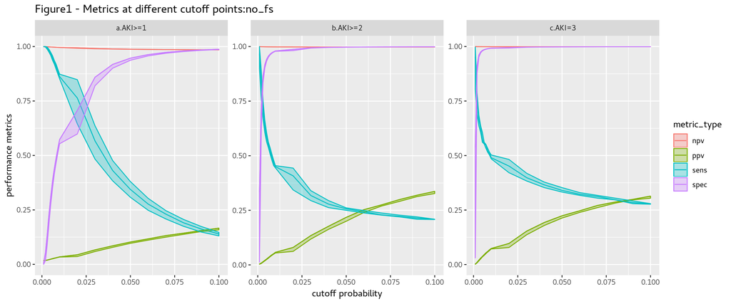

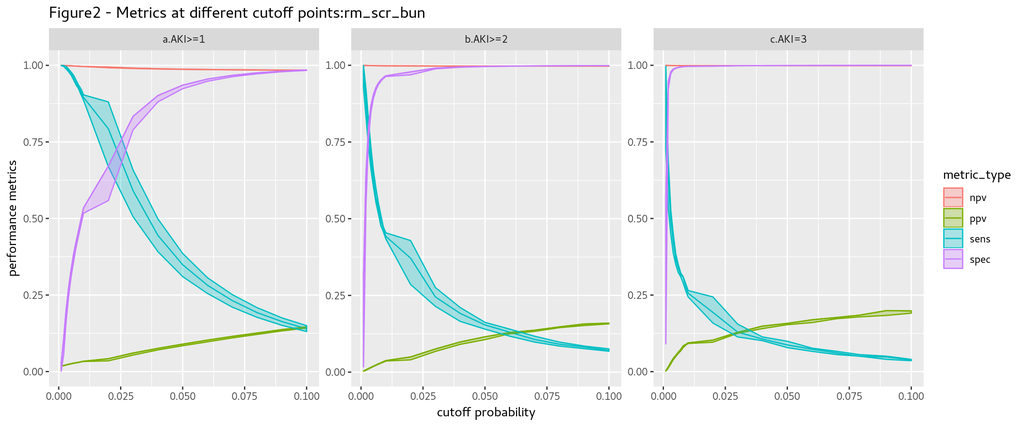

*(I.c) Calibration Plots*

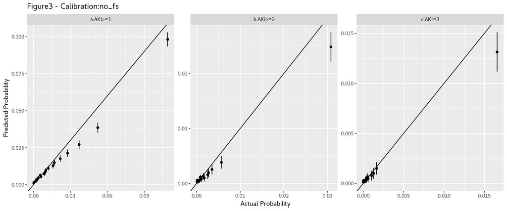

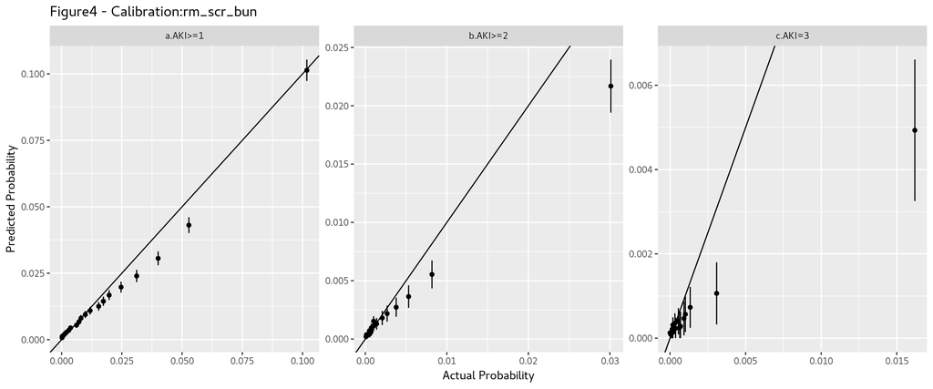

*(I.d) Top Importance Variables*

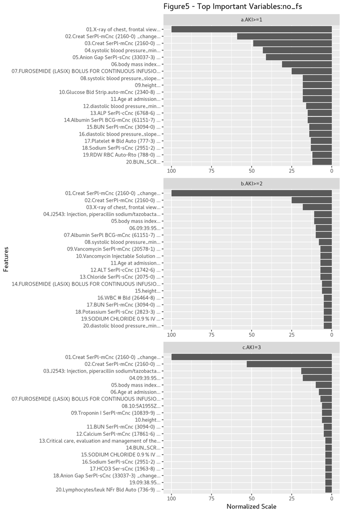

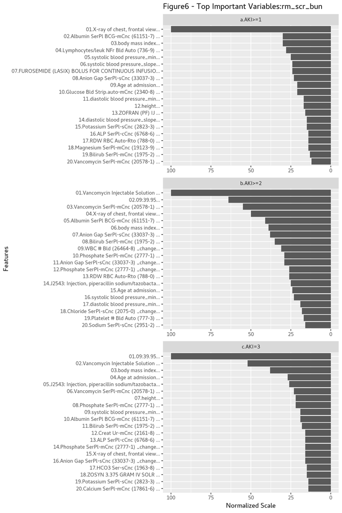

##### Task II: 48-hour advanced prediction

*(II.a) Overall Prediction Performance*

Table2 - 48-Hour Prediction of AKI1, AKI2, AKI3

| pred_task | pred_in_d | fs_type | 1.ROAUC | 2.PRAUC | 3.Optimal Sensitivity | 4.Optimal Specificity | 5.Optimal Positive Predictive Value | 6.Optimal Negative Predictive Value |
| --- | --- | --- | --- | --- | --- | --- | --- | --- |
| a.AKI>=1 | 2 | no_fs | 0.7608 (0.7556,0.766) | 0.0796 | 0.6901 | 0.6816 | 0.0424 | 0.9908 |
| a.AKI>=1 | 2 | rm_scr_bun | 0.7542 (0.749,0.7594) | 0.0704 | 0.6910 | 0.6735 | 0.0414 | 0.9907 |
| b.AKI>=2 | 2 | no_fs | 0.829 (0.8167,0.8412) | 0.0886 | 0.7327 | 0.7653 | 0.0104 | 0.9988 |
| b.AKI>=2 | 2 | rm_scr_bun | 0.8157 (0.8032,0.8283) | 0.0402 | 0.7494 | 0.7261 | 0.0091 | 0.9988 |
| c.AKI=3 | 2 | no_fs | 0.8719 (0.8552,0.8886) | 0.1061 | 0.7861 | 0.8086 | 0.0060 | 0.9996 |
| c.AKI=3 | 2 | rm_scr_bun | 0.8598 (0.843,0.8766) | 0.0405 | 0.7692 | 0.7998 | 0.0056 | 0.9996 |

*(II.b) Full metric paths at various cutoff points*

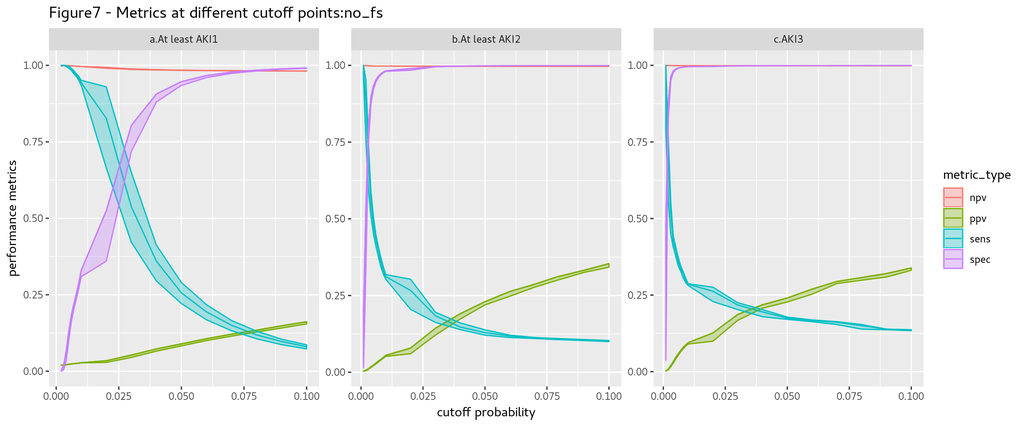

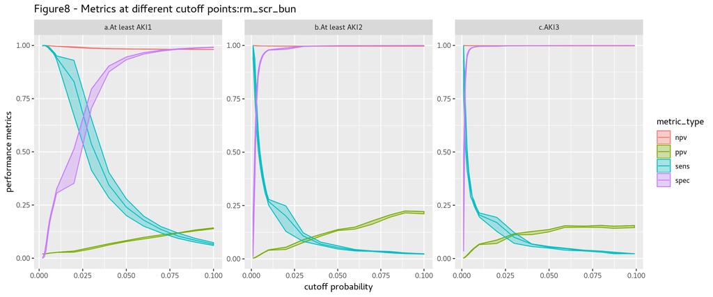

*(II.c) Calibration Plots*

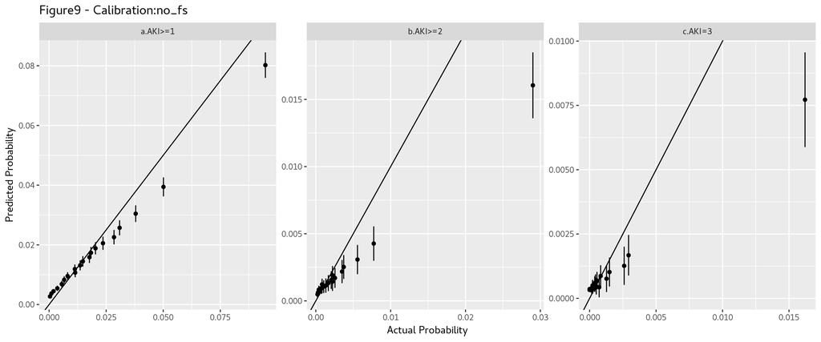

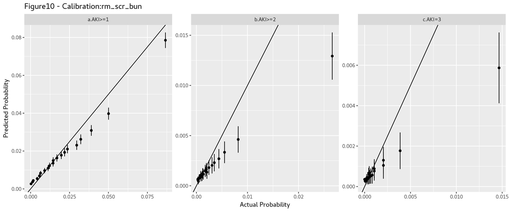

*(II.d) Top Importance Variables*

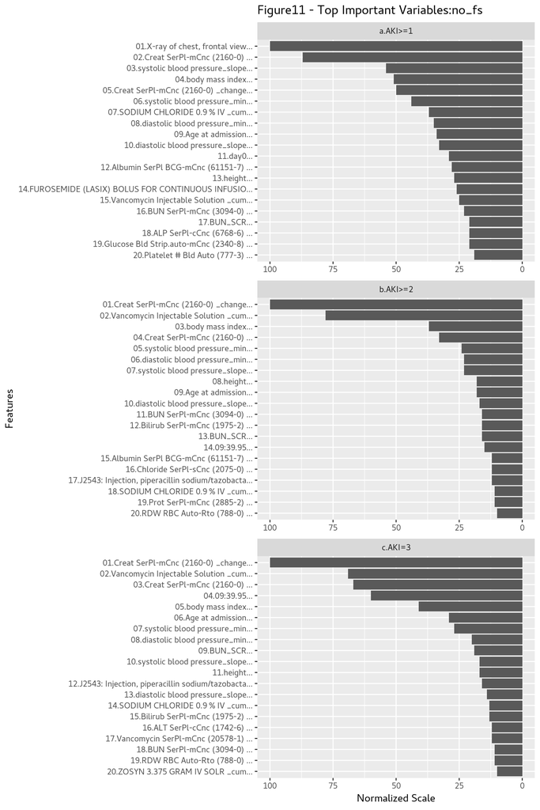

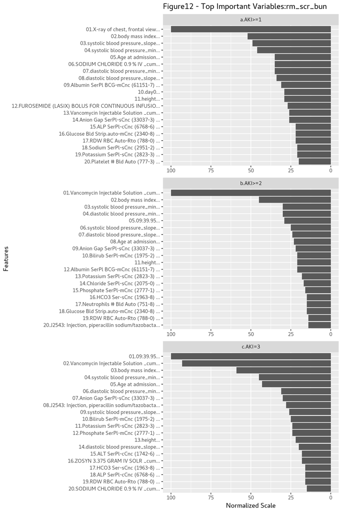